# Case study on Credit Risk

# Thera Bank Personal Loan CampaignData Description:

The dataset contains data on 5000 customers. The data include customer demographic information (age, income, etc.), the customer's relationship with the bank (mortgage, securities account, etc.), and the customer response to the last personal loan campaign (Personal Loan). Among these 5000 customers, only 480 (= 9.6%) accepted the personal loan that was offered to them in the earlier campaign.

Domain:

Banking

Context:

This case is about a bank (TheraBank) whose management wants to explore ways of converting its liability customers to personal loan customers (while retaining them as depositors). A campaign that the bank ran last year for liability customers showed a healthy conversion rate of over 9% success. This has encouraged the retail marketing department to devise campaigns with better target marketing to increase the success ratio with a minimal budget.

```python
# Attribute Information:
#CustomerID
#Age: Customer's age in completed years
#Experience: #years of professional experience
#Income: Annual income of the customer($000)
#ZIP Code: Home Address ZIPcode.
#Family: Family size of the customer
#CCAvg: Avg. spending on credit cards per month($000)
#Education: Education Level. 1: Undergrad; 2: Graduate;3:  Advanced/Professional
#Mortgage: Value of house mortgage if any.($000)
#PersonalLoan:Did this customer accept the personal loan offeredin the last campaign?
#SecuritiesAccount:Does the customer have a securities account with the bank?
#CDAccount:Does the customer have a certificate of deposit (CD) account with the bank?
#Online: Does the customer use internet banking facilities?
#Creditcard:Does the customer use a credit card issued by the bank?

#Project Git link : https://github.com/GreatLearningAIML1/gl-pgp-aiml-uta-intl-may20-koulvivek/tree/master/Project_Personal_Load_Campaign
```

```python
import warnings
warnings.filterwarnings('ignore')
```

```python
#Import the libraries
import numpy as np
import os,sys
import pandas as pd

# importing ploting libraries
import matplotlib.pyplot as plt
# To enable plotting graphs in Jupyter notebook
%matplotlib inline

#importing seaborn for statistical plots
import seaborn as sns

#Let us break the X and y dataframes into training set and test set. For this we will use
#Sklearn package's data splitting function which is based on random function
from sklearn.linear_model import LogisticRegression
from sklearn.model_selection import train_test_split
from sklearn import linear_model
import statsmodels.api as sm
from scipy import stats

# calculate accuracy measures and confusion matrix
from sklearn import metrics
%matplotlib inline

#logistic regression stats
from scipy import stats
```

# Import the datasets and libraries, check datatype, statistical summary, shape, null values or incorrect imputation. (5 marks)

```python
#Import the datasets
loanData = pd.read_csv("Bank_Personal_Loan_Modelling.csv")
loanData.head()
```

|  | ID | Age | Experience | Income | ZIP Code | Family | CCAvg | Education | Mortgage | Personal Loan | Securities Account | CD Account | Online | CreditCard |
| --- | --- | --- | --- | --- | --- | --- | --- | --- | --- | --- | --- | --- | --- | --- |
| 0 | 1 | 25 | 1 | 49 | 91107 | 4 | 1.6 | 1 | 0 | 0 | 1 | 0 | 0 | 0 |
| 1 | 2 | 45 | 19 | 34 | 90089 | 3 | 1.5 | 1 | 0 | 0 | 1 | 0 | 0 | 0 |
| 2 | 3 | 39 | 15 | 11 | 94720 | 1 | 1.0 | 1 | 0 | 0 | 0 | 0 | 0 | 0 |
| 3 | 4 | 35 | 9 | 100 | 94112 | 1 | 2.7 | 2 | 0 | 0 | 0 | 0 | 0 | 0 |
| 4 | 5 | 35 | 8 | 45 | 91330 | 4 | 1.0 | 2 | 0 | 0 | 0 | 0 | 0 | 1 |

```python
# Check Shape of data
loanData.shape
```

```
(5000, 14)
```

```python
# Describe the data
loanData.describe()
```

|  | ID | Age | Experience | Income | ZIP Code | Family | CCAvg | Education | Mortgage | Personal Loan | Securities Account | CD Account | Online | CreditCard |
| --- | --- | --- | --- | --- | --- | --- | --- | --- | --- | --- | --- | --- | --- | --- |
| count | 5000.000000 | 5000.000000 | 5000.000000 | 5000.000000 | 5000.000000 | 5000.000000 | 5000.000000 | 5000.000000 | 5000.000000 | 5000.000000 | 5000.000000 | 5000.00000 | 5000.000000 | 5000.000000 |
| mean | 2500.500000 | 45.338400 | 20.104600 | 73.774200 | 93152.503000 | 2.396400 | 1.937938 | 1.881000 | 56.498800 | 0.096000 | 0.104400 | 0.06040 | 0.596800 | 0.294000 |
| std | 1443.520003 | 11.463166 | 11.467954 | 46.033729 | 2121.852197 | 1.147663 | 1.747659 | 0.839869 | 101.713802 | 0.294621 | 0.305809 | 0.23825 | 0.490589 | 0.455637 |
| min | 1.000000 | 23.000000 | -3.000000 | 8.000000 | 9307.000000 | 1.000000 | 0.000000 | 1.000000 | 0.000000 | 0.000000 | 0.000000 | 0.00000 | 0.000000 | 0.000000 |
| 25% | 1250.750000 | 35.000000 | 10.000000 | 39.000000 | 91911.000000 | 1.000000 | 0.700000 | 1.000000 | 0.000000 | 0.000000 | 0.000000 | 0.00000 | 0.000000 | 0.000000 |
| 50% | 2500.500000 | 45.000000 | 20.000000 | 64.000000 | 93437.000000 | 2.000000 | 1.500000 | 2.000000 | 0.000000 | 0.000000 | 0.000000 | 0.00000 | 1.000000 | 0.000000 |
| 75% | 3750.250000 | 55.000000 | 30.000000 | 98.000000 | 94608.000000 | 3.000000 | 2.500000 | 3.000000 | 101.000000 | 0.000000 | 0.000000 | 0.00000 | 1.000000 | 1.000000 |
| max | 5000.000000 | 67.000000 | 43.000000 | 224.000000 | 96651.000000 | 4.000000 | 10.000000 | 3.000000 | 635.000000 | 1.000000 | 1.000000 | 1.00000 | 1.000000 | 1.000000 |

```python
# check the  datatype
loanData.dtypes
# No object types found , only int and float data present
```

```
ID                      int64
Age                     int64
Experience              int64
Income                  int64
ZIP Code                int64
Family                  int64
CCAvg                 float64
Education               int64
Mortgage                int64
Personal Loan           int64
Securities Account      int64
CD Account              int64
Online                  int64
CreditCard              int64
dtype: object
```

```python
# Check for null values in the data
print(loanData.isnull().values.any()) # null values in data set ?
loanData.isna().sum() # sum of null values.
```

```
False
```

```
ID                    0
Age                   0
Experience            0
Income                0
ZIP Code              0
Family                0
CCAvg                 0
Education             0
Mortgage              0
Personal Loan         0
Securities Account    0
CD Account            0
Online                0
CreditCard            0
dtype: int64
```

```python
# Incorrect Imputations
# There are no null values.
# No object types found , only int and float data present
```

# EDA: Study the data distribution in each attribute and target variable, share your findings (20 marks)

```
Number of unique in each column?
Numberof people with zero mortgage?
Number of people with zero credit card spending per month?
Value counts of all categorical columns.
Univariate and Bivariate
Get data model ready
```

```python
#Number of unique values in each column
uniqueVal = loanData.nunique()
print('Number of unique values in each column :')
print(uniqueVal)
```

```
Number of unique values in each column :
ID                    5000
Age                     45
Experience              47
Income                 162
ZIP Code               467
Family                   4
CCAvg                  108
Education                3
Mortgage               347
Personal Loan            2
Securities Account       2
CD Account               2
Online                   2
CreditCard               2
dtype: int64
```

```python
#Number of people with zero mortgage:
mortgage_data = loanData[loanData["Mortgage"]==0].count()
#print using iloc
print("Number of people with zero mortgage: {0}".format(mortgage_data.iloc[8]))
```

```
Number of people with zero mortgage: 3462
```

```python
#Number of people with zero credit card spending can be calculated by figuring avg spending
credit_data = loanData[loanData["CCAvg"]==0].count()
#print(credit_data)
#print using iloc
print("Number of people with zero credit card spending: {0}".format(credit_data.iloc[13]))
```

```
Number of people with zero credit card spending: 106
```

```python
# Showing all Catagorical data: By looking into the data following fields are looking catagorical
# Education,Family,Securities,Personal Loan, Account,CD Account,Online,CreditCard
# counts of all categorical columns printed..
print(loanData['Family'].value_counts())
print(loanData['Education'].value_counts())
print(loanData['Personal Loan'].value_counts())
print(loanData['Securities Account'].value_counts())
print(loanData['CD Account'].value_counts())
print(loanData['Online'].value_counts())
print(loanData['CreditCard'].value_counts())
```

```
1    1472
2    1296
4    1222
3    1010
Name: Family, dtype: int64
1    2096
3    1501
2    1403
Name: Education, dtype: int64
0    4520
1     480
Name: Personal Loan, dtype: int64
0    4478
1     522
Name: Securities Account, dtype: int64
0    4698
1     302
Name: CD Account, dtype: int64
1    2984
0    2016
Name: Online, dtype: int64
0    3530
1    1470
Name: CreditCard, dtype: int64
```

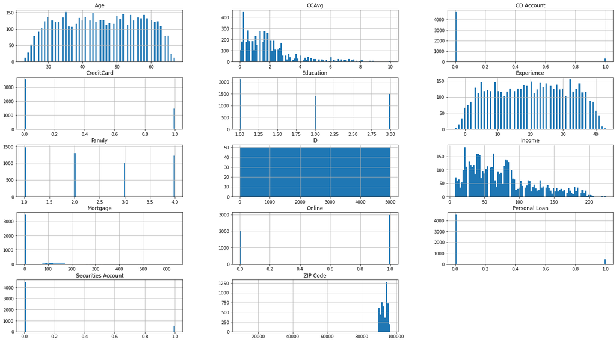

```python
#Univariate Analysis with histogram
loanData.hist(stacked=True, bins=100, figsize=(25,40), layout=(14,3));
```

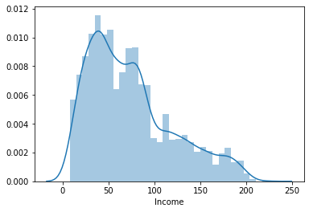

```python
#Univariate Income
sns.distplot(loanData.Income)
```

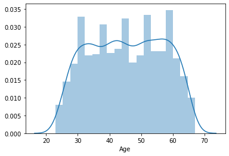

```python
#Univariate Age
sns.distplot(loanData.Age)
```

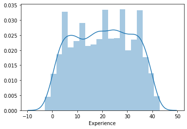

```python
#Univariate Experience
sns.distplot(loanData.Experience)
```

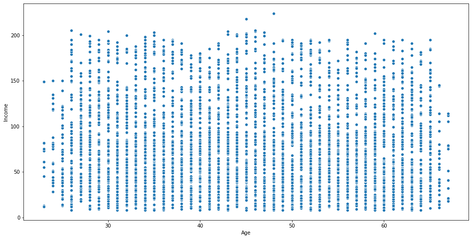

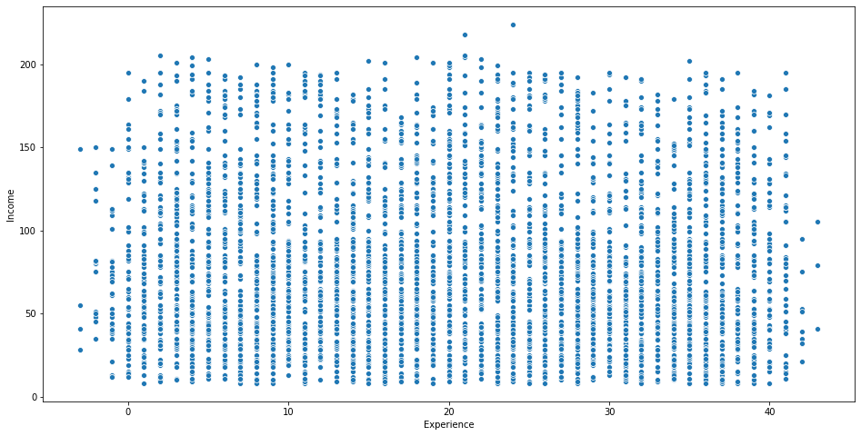

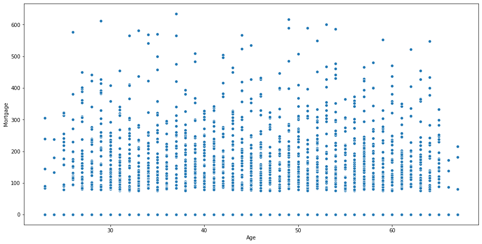

```python
#Bivariate Analysis using scatter plot
#Age vs Income
plt.figure(figsize=(16, 8))
sns.scatterplot(x="Age", y="Income", data = loanData)

#Experience vs Income
plt.figure(figsize=(16, 8))
sns.scatterplot(x="Experience", y="Income", data = loanData)

#Age vs Mortgage
plt.figure(figsize=(16, 8))
sns.scatterplot(x="Age", y="Mortgage", data = loanData)
```

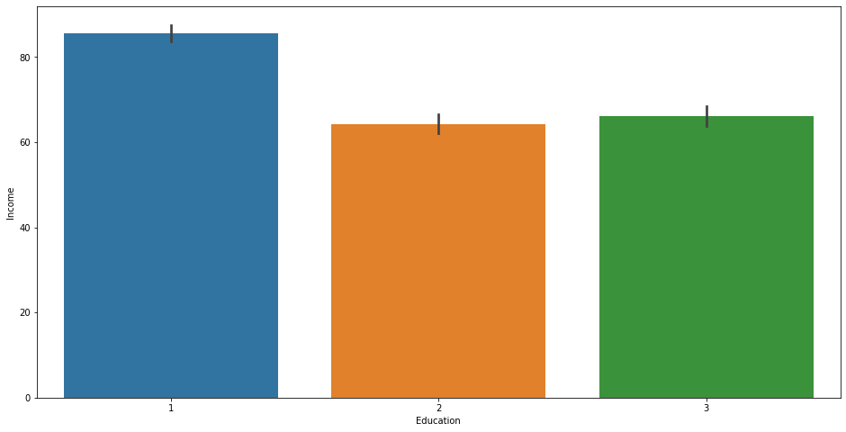

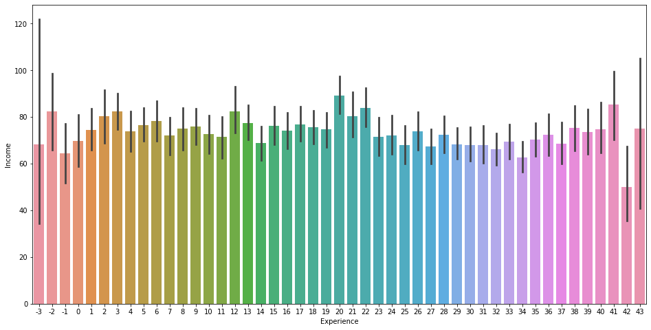

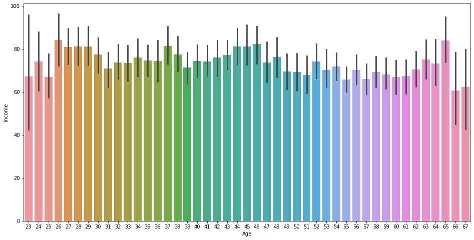

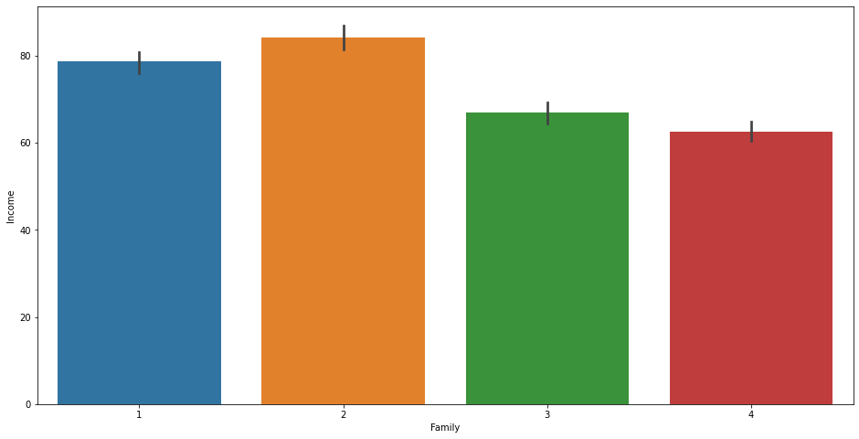

```python
#Bivariate Analysis using barplot

plt.figure(figsize=(16,8))
a = sns.barplot(x='Education', y='Income', data=loanData)

plt.figure(figsize=(16,8))
a = sns.barplot(x='Experience', y='Income', data=loanData)

plt.figure(figsize=(16,8))
a = sns.barplot(x='Age', y='Income', data=loanData)

plt.figure(figsize=(16,8))
a = sns.barplot(x='Family', y='Income', data=loanData)
# from plots it looks like Experience has some negative values ,Family and Education need dummies
```

```python
#GET Data Model Ready .....
```

```python
# Do the Corelation
```

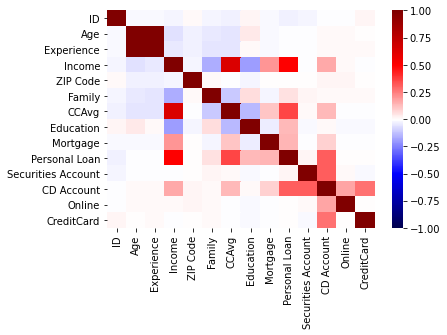

```python
# apply zscore and plot the correlation coefficients as a heatmap

# Z score to get the data unitless
from scipy.stats import zscore
loanData_z = loanData.apply(zscore)

sns.heatmap(loanData_z.corr(),vmin=-1,vmax=1,cmap='seismic')

# Correlation of Age and Experience is very high.
# Personal loan as a target variable has some level of correlation with Income,CCAvg and CD Account.
# Customer currently having deposit accounts or security account  have more chances of getting personal loan.
```

```python
# As deduced earlier 'Experience' has negative values which would need to be replaced with median.
# Zipcode is not useful data and can be dropped
#Also we need to create Dummy data for Categorical variables 'Education' and 'Family'

#find out number of negative rows in Experience colum
print('Count of -ve rows in the Experience column:')
print(loanData[loanData['Experience'] < 0]['Experience'].count())

# replace the negative values with median value
loanData = loanData.mask(loanData < 0, np.nan)
medianFiller = lambda x: x.fillna(x.median())
loanData = loanData.apply(medianFiller,axis=0)

print('Count of -ve rows in the Experience column after median replacement :')
print(loanData[loanData['Experience'] < 0]['Experience'].count())
```

```
Count of -ve rows in the Experience column:
52
Count of -ve rows in the Experience column after median replacement :
0
```

```python
# Drop Zipcode and ID ....doesnt seem to be useful data we can drop it
loanData = loanData.drop(['ZIP Code'], axis=1)
loanData = loanData.drop(['ID'], axis=1)
loanData.reset_index()
# create Dummy data for Categorical variables 'Education' and 'Family'
loanData = pd.get_dummies(loanData, columns=['Family', 'Education'])
loanData.head()
```

|  | Age | Experience | Income | CCAvg | Mortgage | Personal Loan | Securities Account | CD Account | Online | CreditCard | Family_1 | Family_2 | Family_3 | Family_4 | Education_1 | Education_2 | Education_3 |
| --- | --- | --- | --- | --- | --- | --- | --- | --- | --- | --- | --- | --- | --- | --- | --- | --- | --- |
| 0 | 25 | 1.0 | 49 | 1.6 | 0 | 0 | 1 | 0 | 0 | 0 | 0 | 0 | 0 | 1 | 1 | 0 | 0 |
| 1 | 45 | 19.0 | 34 | 1.5 | 0 | 0 | 1 | 0 | 0 | 0 | 0 | 0 | 1 | 0 | 1 | 0 | 0 |
| 2 | 39 | 15.0 | 11 | 1.0 | 0 | 0 | 0 | 0 | 0 | 0 | 1 | 0 | 0 | 0 | 1 | 0 | 0 |
| 3 | 35 | 9.0 | 100 | 2.7 | 0 | 0 | 0 | 0 | 0 | 0 | 1 | 0 | 0 | 0 | 0 | 1 | 0 |
| 4 | 35 | 8.0 | 45 | 1.0 | 0 | 0 | 0 | 0 | 0 | 1 | 0 | 0 | 0 | 1 | 0 | 1 | 0 |

# Split the data into training and test set in the ratio of 70:30 respectively (5 marks)

```python
# Define X and Y  and dependent variable
X = loanData.drop(['Personal Loan'], axis=1)
y = loanData[['Personal Loan']]

# Split  into training and test set in 70:30 ratio
X_train, X_test, y_train, y_test = train_test_split(X, y, test_size=0.30, random_state=1)
X_train.head()
```

|  | Age | Experience | Income | CCAvg | Mortgage | Securities Account | CD Account | Online | CreditCard | Family_1 | Family_2 | Family_3 | Family_4 | Education_1 | Education_2 | Education_3 |
| --- | --- | --- | --- | --- | --- | --- | --- | --- | --- | --- | --- | --- | --- | --- | --- | --- |
| 1334 | 47 | 22.0 | 35 | 1.3 | 0 | 0 | 0 | 1 | 0 | 0 | 1 | 0 | 0 | 1 | 0 | 0 |
| 4768 | 38 | 14.0 | 39 | 2.0 | 0 | 0 | 0 | 1 | 0 | 1 | 0 | 0 | 0 | 0 | 1 | 0 |
| 65 | 59 | 35.0 | 131 | 3.8 | 0 | 0 | 0 | 1 | 1 | 1 | 0 | 0 | 0 | 1 | 0 | 0 |
| 177 | 29 | 3.0 | 65 | 1.8 | 244 | 0 | 0 | 0 | 0 | 0 | 0 | 0 | 1 | 0 | 1 | 0 |
| 4489 | 39 | 13.0 | 21 | 0.2 | 0 | 0 | 0 | 1 | 0 | 0 | 0 | 1 | 0 | 0 | 1 | 0 |

```python
# Shape of Train and Test data
X_train.shape
```

```
(3500, 16)
```

```python
X_test.shape
```

```
(1500, 16)
```

```python
print("{0:0.2f}% data in training set".format((len(X_train)/len(loanData.index)) * 100))
print("{0:0.2f}% data in test set".format((len(X_test)/len(loanData.index)) * 100))
```

```
70.00% data in training set
30.00% data in test set
```

# Use Logistic Regression model to predict the number of a customers buying personal loans. Print all the metrics related for evaluating the model performance (15 marks)

```python
from sklearn import metrics
from sklearn.linear_model import LogisticRegression

# Fit the model using liblinear
model = LogisticRegression(solver="liblinear")
model.fit(X_train, y_train)
#predict on test
y_predict = model.predict(X_test)
X_train.head()
```

|  | Age | Experience | Income | CCAvg | Mortgage | Securities Account | CD Account | Online | CreditCard | Family_1 | Family_2 | Family_3 | Family_4 | Education_1 | Education_2 | Education_3 |
| --- | --- | --- | --- | --- | --- | --- | --- | --- | --- | --- | --- | --- | --- | --- | --- | --- |
| 1334 | 47 | 22.0 | 35 | 1.3 | 0 | 0 | 0 | 1 | 0 | 0 | 1 | 0 | 0 | 1 | 0 | 0 |
| 4768 | 38 | 14.0 | 39 | 2.0 | 0 | 0 | 0 | 1 | 0 | 1 | 0 | 0 | 0 | 0 | 1 | 0 |
| 65 | 59 | 35.0 | 131 | 3.8 | 0 | 0 | 0 | 1 | 1 | 1 | 0 | 0 | 0 | 1 | 0 | 0 |
| 177 | 29 | 3.0 | 65 | 1.8 | 244 | 0 | 0 | 0 | 0 | 0 | 0 | 0 | 1 | 0 | 1 | 0 |
| 4489 | 39 | 13.0 | 21 | 0.2 | 0 | 0 | 0 | 1 | 0 | 0 | 0 | 1 | 0 | 0 | 1 | 0 |

```python
model_score = model.score(X_test, y_test)
print("Trainig accuracy",model.score(X_train,y_train))
print()
print("Testing accuracy",model.score(X_test, y_test))
print()
```

```
Trainig accuracy 0.9611428571428572

Testing accuracy 0.9533333333333334
```

```python
# Get key metrics for model performance
from sklearn.metrics import accuracy_score,f1_score,roc_curve,auc,confusion_matrix,recall_score,precision_score
f1_score = f1_score(y_test,y_predict)
print("******* Key Metrics in Evaluating the Model *******")
print("F1 Score:",f1_score)
accuracy=accuracy_score(y_test,y_predict)
print("Accuracy:", accuracy)
fpr,tpr,_= metrics.roc_curve(y_test,y_predict)
auc= metrics.auc(fpr,tpr)
print("AUC", auc)
precision = metrics.precision_score(y_test, y_predict)
print("Precision:", precision)
recall = metrics.recall_score(y_test, y_predict)
print("Recall:", recall)
```

```
******* Key Metrics in Evaluating the Model *******
F1 Score: 0.7177419354838711
Accuracy: 0.9533333333333334
AUC 0.7949567558706203
Precision: 0.898989898989899
Recall: 0.5973154362416108
```

```
Trainig accuracy 0.9611428571428572

Testing accuracy 0.9533333333333334

Confusion Matrix
```

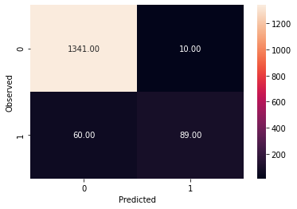

```
None
```

```python
## function to get confusion matrix in a proper format
def draw_cm( actual, predicted ):
    cm = confusion_matrix( actual, predicted)
    sns.heatmap(cm, annot=True,  fmt='.2f', xticklabels = [0,1] , yticklabels = [0,1] )
    plt.ylabel('Observed')
    plt.xlabel('Predicted')
    plt.show()
print("Trainig accuracy",model.score(X_train,y_train))
print()
print("Testing accuracy",model.score(X_test, y_test))
print()
print('Confusion Matrix')
print(draw_cm(y_test,y_predict))
```

Total customers in Testing data set : 1500

True Positives (TP): correctly predicted that customer will buy a personal loan 89

True Negatives (TN): correctly predicted that customer will not buy a personal loan 1341

False Positives (FP): incorrectly predicted that customer will buy a peronal loan (a "Type I error") 10

False Negatives (FN): incorrectly predicted that customer will not buy a personal loan (a "Type II error") 60

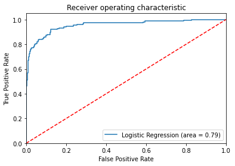

```python
# AUC and ROC Curves

from sklearn.metrics import roc_auc_score
from sklearn.metrics import roc_curve
#take default threshold
liblinear_roc_auc = roc_auc_score(y_test, model.predict(X_test))
fpr, tpr, thresholds = roc_curve(y_test, model.predict_proba(X_test)[:,1])
plt.figure()
plt.plot(fpr, tpr, label='Logistic Regression (area = %0.2f)' % liblinear_roc_auc)
plt.plot([0, 1], [0, 1],'r--')
plt.xlim([0.0, 1.0])
plt.ylim([0.0, 1.05])
plt.xlabel('False Positive Rate')
plt.ylabel('True Positive Rate')
plt.title('Receiver operating characteristic')
plt.legend(loc="lower right")
plt.savefig('Log_ROC')
plt.show()
```

```python
#Print all the metrics related for evaluating the model performance
model_perf_liblinear=pd.DataFrame({'Model':['Logistic Regression-liblinear'],
                    'F1_Score':f1_score,
                    'Accuracy':accuracy,
                    'AUC':auc,
                   'Precision':precision,
                   'Recall':recall})
model_perf_liblinear
```

|  | Model | F1_Score | Accuracy | AUC | Precision | Recall |
| --- | --- | --- | --- | --- | --- | --- |
| 0 | Logistic Regression-liblinear | 0.717742 | 0.953333 | 0.794957 | 0.89899 | 0.597315 |

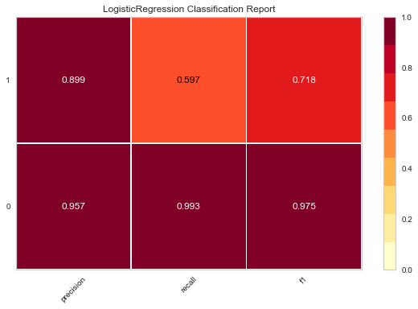

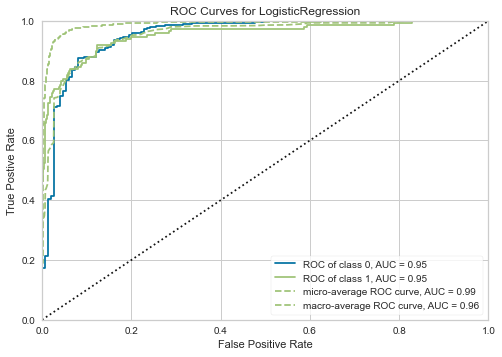

```python
# Additional model performance checks using yellow brick and Classification report

from yellowbrick.classifier import ClassificationReport, ROCAUC
# Visualize model performance with yellowbrick library
viz = ClassificationReport(model)
viz.fit(X_train, y_train)
viz.score(X_test, y_test)
viz.show()

roc = ROCAUC(model)
roc.fit(X_train, y_train)
roc.score(X_test, y_test)
roc.show()
```

# Give your reasoning on how can the model perform better? (10 marks)

```python
# In trails i tried varous solvers and parameters to improve model performance like

    # class_weight as None and 'Balanced'
    # Penalty as 11 /12
    # C from 0 to 10
    #also Earlier we dropped ID and Zipcode that  helped improve the model
# Changing solver to newton-cg and changing C=10 class_weight=None value is giving a better model with better values for performance metrics

model = LogisticRegression(random_state=42,penalty='l2',solver='newton-cg',class_weight=None,C=10) # changing class weight to balanced

model.fit(X_train, y_train)

y_predict = model.predict(X_test)

print("Trainig accuracy",model.score(X_train,y_train))
print()
print("Testing accuracy",model.score(X_test, y_test))
```

```
Trainig accuracy 0.9628571428571429

Testing accuracy 0.958
```

```python
# Get key metrics for model performance
from sklearn.metrics import accuracy_score,f1_score,roc_curve,auc,confusion_matrix,recall_score,precision_score
f1_score_new = f1_score(y_test,y_predict)
print("******* Key Metrics in Evaluating the Model *******")
print("F1 Score:",f1_score_new)
accuracy_new=accuracy_score(y_test,y_predict)
print("Accuracy:", accuracy_new)
fpr,tpr,_= metrics.roc_curve(y_test,y_predict)
auc_new= metrics.auc(fpr,tpr)
print("AUC", auc_new)
precision_new = metrics.precision_score(y_test, y_predict)
print("Precision:", precision_new)
recall_new = metrics.recall_score(y_test, y_predict)
print("Recall:", recall_new)
```

```
******* Key Metrics in Evaluating the Model *******
F1 Score: 0.7509881422924901
Accuracy: 0.958
AUC 0.8154610802835582
Precision: 0.9134615384615384
Recall: 0.6375838926174496
```

```
Trainig accuracy 0.9628571428571429

Testing accuracy 0.958

Confusion Matrix
```

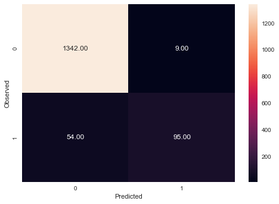

```
None
```

```python
## function to get confusion matrix in a proper format
def draw_cm( actual, predicted ):
    cm = confusion_matrix( actual, predicted)
    sns.heatmap(cm, annot=True,  fmt='.2f', xticklabels = [0,1] , yticklabels = [0,1] )
    plt.ylabel('Observed')
    plt.xlabel('Predicted')
    plt.show()
print("Trainig accuracy",model.score(X_train,y_train))
print()
print("Testing accuracy",model.score(X_test, y_test))
print()
print('Confusion Matrix')
print(draw_cm(y_test,y_predict))
```

"Yayyyy !!! New model has higher TN and lesser FP" Total customers in Testing data set : 1500

True Positives (TP): correctly predicted that customer will buy a personal loan 95

True Negatives (TN): correctly predicted that customer will not buy a personal loan 1342

False Positives (FP): incorrectly predicted that customer will buy a peronal loan (a "Type I error") 9

False Negatives (FN): incorrectly predicted that customer will not buy a personal loan (a "Type II error") 54

```python
#Print all the metrics related for evaluating the model performance with new model
model_perf_liblinear=pd.DataFrame({'Model':['Logistic Regression-newton-cg'],
                    'F1_Score':f1_score_new,
                    'Accuracy':accuracy_new,
                    'AUC':auc_new,
                   'Precision':precision_new,
                   'Recall':recall_new})
model_perf_liblinear
```

|  | Model | F1_Score | Accuracy | AUC | Precision | Recall |
| --- | --- | --- | --- | --- | --- | --- |
| 0 | Logistic Regression-newton-cg | 0.750988 | 0.958 | 0.815461 | 0.913462 | 0.637584 |

```python
#Model	      				      F1_Score      Accuracy    AUC     Precision Recall
#Logistic Regression-liblinear 	0.717742	0.953333	0.794957	0.89899	  0.597315
# Logistic Regression-newton-cg	0.750988	0.958	    0.815461    0.913462    0.637584

# more accuracy,AUC and F1 score
```

# Give Business understanding of your model? (5 marks)

Correlation of Age and Experience is very high.

Dropping of values with low abslute value of coeficients(e.g Zipcode ,ID) improved the accuracy.

Personal loan as a target variable has some level of correlation with Income,CCAvg and CD Account.

Customer currently having CD accounts have more chances of picking a personal loan.

Targetting the customers with existing CD Account would increase the rate of loan acceptance.